# Probability of response vectors in conquestr

Dan Cloney

2023-03-12

# Introduction

In some cases users might like to return the probability of a response on a given item. For example, given a fixed set of item parameters, return the probabilities at varying levels of theta to produce custom probability plots.

# Example

## dichotomous case

The probability of responding correctly to a dichotomous item under Rasch-like models (e.g., 1PL models) is often expressed as:

$$\begin{equation}
p(x_{ni} = 1)=\frac{exp(\theta_{n} - \delta_{i})}{1 + (\theta_{n} -
\delta_{i})}
(\#eq:slm)
\end{equation}$$

Imagine the item parameters of a single item represented as:

```r
library(conquestr)
myItem <- matrix(c(0, 0, 0, 1, 1, 0), ncol =3, byrow=TRUE)
colnames(myItem)<- c("k", "d", "t")
print(myItem)
```

```
#>      k d t
#> [1,] 0 0 0
#> [2,] 1 1 0
```

Then the probability of scoring 0 and 1 on this item, at = 0.5:

```r
myProbs <- simplep(0.5, myItem)
```

```
#> assuming item discrimination is constant and equal to 1
```

```r
print(myProbs)
```

```
#>           [,1]
#> [1,] 0.6224593
#> [2,] 0.3775407
```

A simple ICC can be drawn:

```r
myProbsList <- list()
myThetaRange <- seq(-4, 4, by = 0.1)
for (i in seq(myThetaRange)) {
  myProbsList[[i]] <- pX(x = 1, probs = simplep(myThetaRange[i], myItem))
}
```

[output not shown]

[output cut: 26 more lines]

[output not shown]

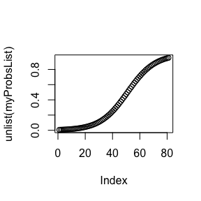

```r
plot(unlist(myProbsList))
```

## polytomous case

In the case of polytomously scored items, the probability model can be generalised:

$$\begin{equation}
p(X_{ni} = x)=\frac{exp\sum\limits_{k=0}^{x}(\theta_{n} - (\delta_{i}
+ \tau_{ik}))}{\sum\limits_{j=0}^{m}exp(\sum\limits_{k=0}^{j}
(\theta_{n} - (\delta_{i} + \tau_{ik})))}
(\#eq:pcm)
\end{equation}$$

An item can them be represented such that:

```r
library(conquestr)
myItem <- matrix(c(0, 0, 0, 1, 1, -0.2, 2, 1, 0.2), ncol =3, byrow=TRUE)
colnames(myItem)<- c("k", "d", "t")
print(myItem)
```

```
#>      k d    t
#> [1,] 0 0  0.0
#> [2,] 1 1 -0.2
#> [3,] 2 1  0.2
```

Then the probability of scoring 0, 1 and 2 on this item, at = 0.5:

```r
myProbs <- simplep(0.5, myItem)
```

```
#> assuming item discrimination is constant and equal to 1
```

```r
print(myProbs)
```

```
#>           [,1]
#> [1,] 0.4742264
#> [2,] 0.3513155
#> [3,] 0.1744581
```

A simple ICC can be drawn:

```r
myProbsList <- list()
myThetaRange <- seq(-4, 4, by = 0.1)
for (i in seq(myThetaRange)) {
  myProbsList[[i]] <- simplep(myThetaRange[i], myItem)
}
```

[output not shown]

[output cut: 26 more lines]

[output not shown]

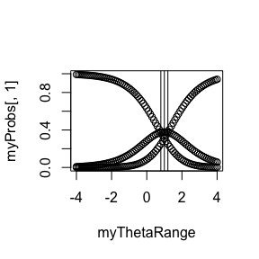

```r
myProbs <- (matrix(unlist(myProbsList), ncol = 3, byrow = TRUE))
plot(myThetaRange, myProbs[,1])
points(myThetaRange, myProbs[,2])
points(myThetaRange, myProbs[,3])
abline(v = c(myItem[2, 2], sum(myItem[2, 2:3]), sum(myItem[3, 2:3])))
```

## Expected scores

The expected score for the an item can be calculated at a given value of theta. Taking an aribitary set of items, it is possible therefor to calculate the test expected score.

```r
library(conquestr)
myItems <- list()
myItems[[1]] <- matrix(c(0, 0, 0, 1, 1, -0.2, 2, 1, 0.2), ncol =3, byrow=TRUE)
myItems[[2]] <- matrix(c(0, 0, 0, 1, -1, -0.4, 2, -1, 0.4), ncol =3, byrow=TRUE)
myItems[[3]] <- matrix(c(0, 0, 0, 1, 1.25, -0.6, 2, 1.25, 0.6), ncol =3, byrow=TRUE)
myItems[[4]] <- matrix(c(0, 0, 0, 1, 2, 0.2, 2, 2, -0.2), ncol =3, byrow=TRUE)
myItems[[5]] <- matrix(c(0, 0, 0, 1, -2.5, -0.2, 2, -2.5, 0.2), ncol =3, byrow=TRUE)
for (i in seq(myItems)) {
  colnames(myItems[[i]])<- c("k", "d", "t")
}
print(myItems)
```

```
#> [[1]]
#>      k d    t
#> [1,] 0 0  0.0
#> [2,] 1 1 -0.2
#> [3,] 2 1  0.2
#>
#> [[2]]
#>      k  d    t
#> [1,] 0  0  0.0
#> [2,] 1 -1 -0.4
#> [3,] 2 -1  0.4
#>
#> [[3]]
#>      k    d    t
#> [1,] 0 0.00  0.0
#> [2,] 1 1.25 -0.6
#> [3,] 2 1.25  0.6
#>
#> [[4]]
#>      k d    t
#> [1,] 0 0  0.0
#> [2,] 1 2  0.2
#> [3,] 2 2 -0.2
#>
#> [[5]]
#>      k    d    t
#> [1,] 0  0.0  0.0
#> [2,] 1 -2.5 -0.2
#> [3,] 2 -2.5  0.2
```

```r
expectedRes <- list()
for (i in seq(myThetaRange)) {
  tmpExp <- 0
  for (j in seq(myItems)) {
    tmpE <- simplef(myThetaRange[i], myItems[[j]])
    tmpExp <- tmpExp + tmpE
  }
  expectedRes[[i]] <- tmpExp
}
```

[output not shown]

[output cut: 350 more lines]

[output not shown]

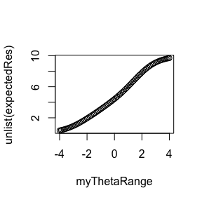

```r
plot(myThetaRange, unlist(expectedRes))
```